# MA256 Lesson 3 - Significance - Strength of Evidence (1.1-1.2)

### Defintions review

**Statistical Significance**

**What is the 3S Strategy?**

What is the difference between a **parameter** and a **statistic**?

**Define:**

**$H_0$** :

**$H_a$** :

**$\pi$** :

**$\hat{p}$** :

**n** :

**p-value** :

*Classify the strength of evidence for each range of p-values.**

## Chips Ahoy vs Keebler Original Chocolate Chip Cookies

Chips Ahoy! conducted a blind taste-test experiment with 50 randomly selected consumers and recorded whether they preferred Chips Ahoy! over Keebler’s original chocolate chip cookies. Of those 50 consumers, 45 (90%) of them preferred Chips Ahoy! Chips Ahoy! now claims that 90% of consumers prefer their cookies over Keebler’s.

**Step 1: Ask a Research Question:** Q1) Restate from the given information.

**Step 2: Design a Study & Collect Data:** Q3) Explain what type of study was conducted.

**Step 3: Explore the Data:** Q4) What could we do with the data to help us understand it better?

**Step 4:** Draw Inferences: Significance (today’s lesson!)

*To draw inferences for this or any other research question, we must set the framework by answering the following questions. Do this at boards in teams of 2-3:*

Q5) What are the observational units?

Q6) What is the sample size and number of samples?

Q7) Identify & classify the variable collected.

Q8) What is the symbol, definition & value of the sample statistic?

Q9) What is the symbol, definition, & value of the population parameter?

$\pi$

Q10) What are the null & alternate hypotheses in words and symbol notation?

Q11) With the framework established, we can use the 3S strategy and *One Proportion* applet (http://www.isi-stats.com/isi2nd/ISIapplets2021.html) to estimate the likelihood that Chips Ahoy got the result they did if consumers could not taste a difference and were randomly choosing one of the two cookies.

**1. Statistic:** Write out the statistic: $\hat{p} = 45 / 50 = 90\% \; or \; 0.9$

**2. Simulate:** Run the simulation using the *One Proportion* applet.

*Getting the Null Distribution:*

Probability of choosing Chips Ahoy! (success/heads) = $\pi$ (Parameter) =

Number of tosses = n (Sample size) =

Number of repetitions =

Select “Draw Samples” button.

**3. Strength of Evidence:**

Q12) How common/uncommon is our observation? Report the p-value. Select the “Count samples” “Count” button to calculate the P-value for this simulation. (What number should you use for the *As extreme as* value?) Did we prove the alternative hypothesis?

**2. Simulate (REDUX):** Run the simulation using R. For help with a `for` loop, see https://www.rdocumentation.org/packages/openintro/versions/2.4.0/topics/loop or type `?Control` in the console.

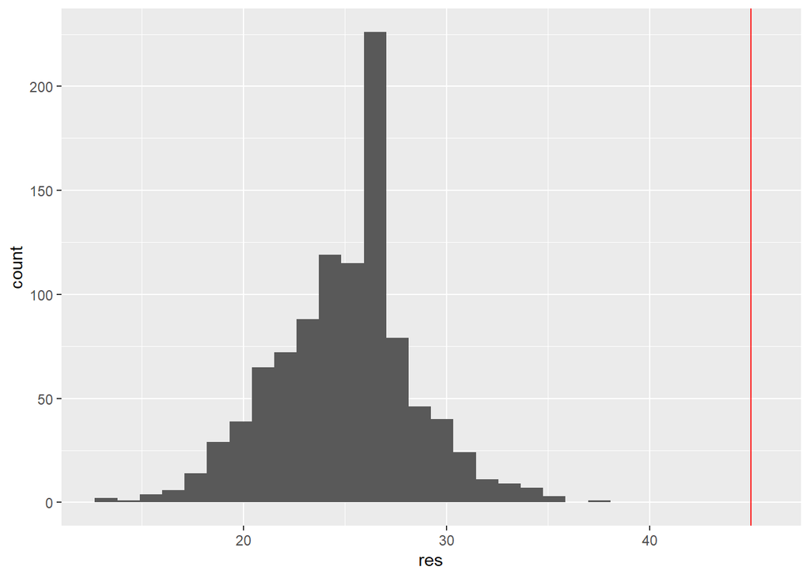

```r
set.seed(256)

M <- 1000         # number of replications
mypi <- 0.5       # population parameter (under the null hypothesis)
n <- 50           # sample size
n.succ <- 45      # number of successes
myphat <- n.succ / n   # observed statistic (proportion of "successes")

RES <- data.frame(res = rep(NA, M))  # create a data frame to hold the results of the simulation

for(rep in 1:M){
  myobs <- rbinom(1, n, mypi)
  RES$res[rep] <- myobs
}

# plot a histogram of the results
RES %>% ggplot(aes(x = res)) + geom_histogram() +
  geom_vline(xintercept = n.succ, color = "red")
```

```r
# estimate p-value
sum(RES$res >= n.succ)
```

```
## [1] 0
```

Q13) What can you conclude from this study?

**Step 5: Formulate Conclusions:**

Q14) Can you generalize to other brands? Can you identify any bias in the study?

**Step 6: Look Back and Ahead:**

Q15) Identify limitations & suggest ways to overcome in new studies.

### A third competitor.

Q16) How would the analysis above change if we introduced a third cookie competitor and conducted the experiment in our classroom?

.

Q17)Is it possible for the observed proportion to match the null hypothesis if the null hypothesis is false? If the null is true?